# Homework: Reading in Data

Example Solutions

## Instructions

Big picture: Read in the Medicare and Medicaid General Payments Data and conduct an exploratory data analysis. You should use both SAS and R to explore the data, but you might choose to use R for certain tasks and SAS for other tasks.

When you are finished with the assignment:

1. Save the file as 04_Lastname_Firstname.Rmd and compile it
2. Commit the Rmd file and corresponding html file to your homework git repo
3. Push the commit to github
4. Locate the Rmd file on github and click on the SHA link for the file
5. Paste the url of the resulting page into Canvas to submit your assignment.

Your assignment must compile on a different computer as long as the saspath is set correctly for that machine. This means you will need to use a local file path when you read the data in via R (and SAS). So when you specify your file path, it should look something like “General_Payment_Data_Sample.csv” with no “/home/xxx/Documents” or “C:\” in front of it.

### About the Data

To get this data, I started with the full 2018 dataset, and limited it to cash payments made to medical doctors reported in January. The full dataset is *way* too big - several GB when stored on disk.

A sample of the full dataset is available in the template repository (and also [here](https://github.com/srvanderplas/unl-stat850/raw/master/data/General_Payment_Data_Sample.csv)). It’s 8MB after extreme trimming of the less useful columns and sampling 25% of the rows. You can read about the data [here](https://openpaymentsdata.cms.gov/about) and [here](https://www.cms.gov/openpayments/).

### Questions to Address

- Describe the dataset and any interesting things you find within.
- What tasks are easier in R? SAS?
- What do you find that might need to be cleaned up or corrected before analysis?

### R

(You don’t need to keep these headings, but I want you to have a skeleton of what the code chunks should look like)

```r
library(readr)
data <- read_csv("https://github.com/srvanderplas/unl-stat850/raw/master/data/General_Payment_Data_Sample.csv")
```

```r
# Load useful packages
library(skimr)   # fancy summary tables
library(tibble)  # fancy data frames
library(dplyr)   # data manipulation
library(ggplot2) # plots

skim(data)
```

Data summary

| Name | data |
| --- | --- |
| Number of rows | 22302 |
| Number of columns | 34 |
| _______________________ |  |
| Column type frequency: |  |
| character | 29 |
| numeric | 5 |
| ________________________ |  |
| Group variables | None |

**Variable type: character**

| skim_variable | n_missing | complete_rate | min | max | empty | n_unique | whitespace |
| --- | --- | --- | --- | --- | --- | --- | --- |
| Change_Type | 0 | 1 | 3 | 9 | 0 | 3 | 0 |
| Recipient_Primary_Business_Street_Address_Line1 | 0 | 1 | 5 | 55 | 0 | 13781 | 0 |
| Recipient_City | 0 | 1 | 2 | 27 | 0 | 3418 | 0 |
| Recipient_State | 0 | 1 | 1 | 2 | 0 | 56 | 0 |
| Recipient_Zip_Code | 0 | 1 | 1 | 10 | 0 | 9274 | 0 |
| Recipient_Country | 0 | 1 | 6 | 18 | 0 | 3 | 0 |
| Recipient_Province | 0 | 1 | 1 | 16 | 0 | 3 | 0 |
| Recipient_Postal_Code | 0 | 1 | 1 | 7 | 0 | 3 | 0 |
| Physician_Specialty | 0 | 1 | 1 | 115 | 0 | 192 | 0 |
| Submitting_Applicable_Manufacturer_or_Applicable_GPO_Name | 0 | 1 | 6 | 77 | 0 | 562 | 0 |
| Applicable_Manufacturer_or_Applicable_GPO_Making_Payment_Name | 0 | 1 | 6 | 77 | 0 | 614 | 0 |
| Applicable_Manufacturer_or_Applicable_GPO_Making_Payment_State | 0 | 1 | 1 | 2 | 0 | 38 | 0 |
| Applicable_Manufacturer_or_Applicable_GPO_Making_Payment_Country | 0 | 1 | 5 | 18 | 0 | 15 | 0 |
| Date_of_Payment | 0 | 1 | 10 | 10 | 0 | 31 | 0 |
| Nature_of_Payment_or_Transfer_of_Value | 0 | 1 | 4 | 146 | 0 | 14 | 0 |
| City_of_Travel | 0 | 1 | 1 | 20 | 0 | 723 | 0 |
| State_of_Travel | 0 | 1 | 1 | 2 | 0 | 52 | 0 |
| Country_of_Travel | 0 | 1 | 1 | 20 | 0 | 34 | 0 |
| Physician_Ownership_Indicator | 0 | 1 | 2 | 3 | 0 | 2 | 0 |
| Third_Party_Payment_Recipient_Indicator | 0 | 1 | 6 | 22 | 0 | 3 | 0 |
| Name_of_Third_Party_Entity_Receiving_Payment_or_Transfer_of_Value | 0 | 1 | 1 | 50 | 0 | 746 | 0 |
| Charity_Indicator | 0 | 1 | 1 | 3 | 0 | 3 | 0 |
| Third_Party_Equals_Covered_Recipient_Indicator | 0 | 1 | 1 | 3 | 0 | 3 | 0 |
| Contextual_Information | 0 | 1 | 1 | 500 | 0 | 456 | 0 |
| Covered_or_Noncovered_Indicator_1 | 0 | 1 | 1 | 11 | 0 | 3 | 0 |
| Indicate_Drug_or_Biological_or_Device_or_Medical_Supply_1 | 0 | 1 | 1 | 14 | 0 | 5 | 0 |
| Product_Category_or_Therapeutic_Area_1 | 0 | 1 | 1 | 77 | 0 | 600 | 0 |
| Name_of_Drug_or_Biological_or_Device_or_Medical_Supply_1 | 0 | 1 | 1 | 95 | 0 | 1453 | 0 |
| Associated_Drug_or_Biological_NDC_1 | 0 | 1 | 1 | 12 | 0 | 386 | 0 |

**Variable type: numeric**

| skim_variable | n_missing | complete_rate | mean | sd | p0 | p25 | p50 | p75 | p100 | hist |
| --- | --- | --- | --- | --- | --- | --- | --- | --- | --- | --- |
| Physician_Profile_ID | 0 | 1 | 4.12e+05 | 5.58e+05 | 2.40e+01 | 1.24e+05 | 2.45e+05 | 3.67e+05 | 5.71e+06 | ▇▁▁▁▁ |
| Applicable_Manufacturer_or_Applicable_GPO_Making_Payment_ID | 0 | 1 | 1.00e+11 | 4.79e+04 | 1.00e+11 | 1.00e+11 | 1.00e+11 | 1.00e+11 | 1.00e+11 | ▇▁▁▁▁ |
| Total_Amount_of_Payment_USDollars | 0 | 1 | 9.61e+02 | 7.41e+03 | 1.10e-01 | 1.32e+01 | 2.27e+01 | 3.34e+02 | 5.07e+05 | ▇▁▁▁▁ |
| Number_of_Payments_Included_in_Total_Amount | 0 | 1 | 1.03e+00 | 5.50e-01 | 1.00e+00 | 1.00e+00 | 1.00e+00 | 1.00e+00 | 3.00e+01 | ▇▁▁▁▁ |
| Record_ID | 0 | 1 | 5.85e+08 | 2.58e+07 | 5.21e+08 | 5.68e+08 | 5.91e+08 | 6.08e+08 | 6.18e+08 | ▂▂▅▃▇ |

From the `skimr` summary table, we can see that none of the variables have missing data (which is really odd), and many of the character variables have only 2-5 unique values. If we investigate, though, we find something interesting:

```r
table(data$Recipient_Country)
```

```
##
##             Canada Great Britain (Uk)      United States
##                  1                  1              22300
```

```r
table(data$Recipient_Province)
```

```
##
##                . BRITISH COLUMBIA           LONDON
##            22300                1                1
```

```r
table(data$Recipient_Postal_Code)
```

```
##
##       .  V4E2Z6 W1G 7LA
##   22300       1       1
```

```r
table(data$Recipient_Country)
```

```
##
##             Canada Great Britain (Uk)      United States
##                  1                  1              22300
```

It appears missing values are indicated with a ‘.’, as in SAS, and not with an NA, as is standard in R. We can fix that with an option to `read_csv`:

```r
data <- read_csv("https://github.com/srvanderplas/unl-stat850/raw/master/data/General_Payment_Data_Sample.csv", na = '.')
skim(data)
```

Data summary

| Name | data |
| --- | --- |
| Number of rows | 22302 |
| Number of columns | 34 |
| _______________________ |  |
| Column type frequency: |  |
| character | 29 |
| numeric | 5 |
| ________________________ |  |
| Group variables | None |

**Variable type: character**

| skim_variable | n_missing | complete_rate | min | max | empty | n_unique | whitespace |
| --- | --- | --- | --- | --- | --- | --- | --- |
| Change_Type | 0 | 1.00 | 3 | 9 | 0 | 3 | 0 |
| Recipient_Primary_Business_Street_Address_Line1 | 0 | 1.00 | 5 | 55 | 0 | 13781 | 0 |
| Recipient_City | 0 | 1.00 | 2 | 27 | 0 | 3418 | 0 |
| Recipient_State | 2 | 1.00 | 2 | 2 | 0 | 55 | 0 |
| Recipient_Zip_Code | 2 | 1.00 | 5 | 10 | 0 | 9273 | 0 |
| Recipient_Country | 0 | 1.00 | 6 | 18 | 0 | 3 | 0 |
| Recipient_Province | 22300 | 0.00 | 6 | 16 | 0 | 2 | 0 |
| Recipient_Postal_Code | 22300 | 0.00 | 6 | 7 | 0 | 2 | 0 |
| Physician_Specialty | 7 | 1.00 | 24 | 115 | 0 | 191 | 0 |
| Submitting_Applicable_Manufacturer_or_Applicable_GPO_Name | 0 | 1.00 | 6 | 77 | 0 | 562 | 0 |
| Applicable_Manufacturer_or_Applicable_GPO_Making_Payment_Name | 0 | 1.00 | 6 | 77 | 0 | 614 | 0 |
| Applicable_Manufacturer_or_Applicable_GPO_Making_Payment_State | 371 | 0.98 | 2 | 2 | 0 | 37 | 0 |
| Applicable_Manufacturer_or_Applicable_GPO_Making_Payment_Country | 0 | 1.00 | 5 | 18 | 0 | 15 | 0 |
| Date_of_Payment | 0 | 1.00 | 10 | 10 | 0 | 31 | 0 |
| Nature_of_Payment_or_Transfer_of_Value | 0 | 1.00 | 4 | 146 | 0 | 14 | 0 |
| City_of_Travel | 19784 | 0.11 | 3 | 20 | 0 | 722 | 0 |
| State_of_Travel | 19901 | 0.11 | 2 | 2 | 0 | 51 | 0 |
| Country_of_Travel | 19784 | 0.11 | 4 | 20 | 0 | 33 | 0 |
| Physician_Ownership_Indicator | 0 | 1.00 | 2 | 3 | 0 | 2 | 0 |
| Third_Party_Payment_Recipient_Indicator | 0 | 1.00 | 6 | 22 | 0 | 3 | 0 |
| Name_of_Third_Party_Entity_Receiving_Payment_or_Transfer_of_Value | 21203 | 0.05 | 4 | 50 | 0 | 745 | 0 |
| Charity_Indicator | 13951 | 0.37 | 2 | 3 | 0 | 2 | 0 |
| Third_Party_Equals_Covered_Recipient_Indicator | 21079 | 0.05 | 2 | 3 | 0 | 2 | 0 |
| Contextual_Information | 20934 | 0.06 | 1 | 500 | 0 | 455 | 0 |
| Covered_or_Noncovered_Indicator_1 | 1918 | 0.91 | 7 | 11 | 0 | 2 | 0 |
| Indicate_Drug_or_Biological_or_Device_or_Medical_Supply_1 | 2329 | 0.90 | 4 | 14 | 0 | 4 | 0 |
| Product_Category_or_Therapeutic_Area_1 | 2404 | 0.89 | 1 | 77 | 0 | 599 | 0 |
| Name_of_Drug_or_Biological_or_Device_or_Medical_Supply_1 | 2507 | 0.89 | 2 | 95 | 0 | 1452 | 0 |
| Associated_Drug_or_Biological_NDC_1 | 10126 | 0.55 | 12 | 12 | 0 | 385 | 0 |

**Variable type: numeric**

| skim_variable | n_missing | complete_rate | mean | sd | p0 | p25 | p50 | p75 | p100 | hist |
| --- | --- | --- | --- | --- | --- | --- | --- | --- | --- | --- |
| Physician_Profile_ID | 0 | 1 | 4.12e+05 | 5.58e+05 | 2.40e+01 | 1.24e+05 | 2.45e+05 | 3.67e+05 | 5.71e+06 | ▇▁▁▁▁ |
| Applicable_Manufacturer_or_Applicable_GPO_Making_Payment_ID | 0 | 1 | 1.00e+11 | 4.79e+04 | 1.00e+11 | 1.00e+11 | 1.00e+11 | 1.00e+11 | 1.00e+11 | ▇▁▁▁▁ |
| Total_Amount_of_Payment_USDollars | 0 | 1 | 9.61e+02 | 7.41e+03 | 1.10e-01 | 1.32e+01 | 2.27e+01 | 3.34e+02 | 5.07e+05 | ▇▁▁▁▁ |
| Number_of_Payments_Included_in_Total_Amount | 0 | 1 | 1.03e+00 | 5.50e-01 | 1.00e+00 | 1.00e+00 | 1.00e+00 | 1.00e+00 | 3.00e+01 | ▇▁▁▁▁ |
| Record_ID | 0 | 1 | 5.85e+08 | 2.58e+07 | 5.21e+08 | 5.68e+08 | 5.91e+08 | 6.08e+08 | 6.18e+08 | ▂▂▅▃▇ |

And now we’re getting information that looks a bit more plausible. Not all medical reimbursements are e.g. travel related, or would be expected to have associated charity or drug information.

The numeric variables in the dataset are primarily ID numbers, but there are two potentially useful pieces of information: Number of payments included, and total reimbursement amount.

A few other observations from just the table above: - The smallest payment was for $0.11? That’s odd… - Most payments are for <$500, but there are a few really large reimbursements - Almost all records are for single payments.

Let’s pull out the interesting pieces of each of these observations. I’ll use the way you know how to use for now as much as I can (and we’ll learn a better way next week with `dplyr`).

```r
# Smallest payment w/ some context?
data[which.min(data$Total_Amount_of_Payment_USDollars),
     c("Nature_of_Payment_or_Transfer_of_Value", "Recipient_State",
       "Physician_Specialty", "Total_Amount_of_Payment_USDollars")]
```

```
## # A tibble: 1 x 4
##   Nature_of_Payment_… Recipient_State Physician_Specialty     Total_Amount_of_P…
##   <chr>               <chr>           <chr>                                <dbl>
## 1 Food and Beverage   FL              Allopathic & Osteopath…               0.11
```

```r
# Largest payment w/ some context?
data[which.max(data$Total_Amount_of_Payment_USDollars),
     c("Nature_of_Payment_or_Transfer_of_Value", "Recipient_State",
       "Physician_Specialty", "Total_Amount_of_Payment_USDollars", "Contextual_Information")]
```

```
## # A tibble: 1 x 5
##   Nature_of_Payme… Recipient_State Physician_Speci… Total_Amount_of…
##   <chr>            <chr>           <chr>                       <dbl>
## 1 Royalty or Lice… WI              Allopathic & Os…          507211.
## # … with 1 more variable: Contextual_Information <chr>
```

```r
# define a new skim summary function that counts the number of observations
# and gets the mean, sd, and histogram
no_ps <- skim_with(numeric = sfl(mean = mean, sd = sd,
                                 hist = inline_hist, n = length),
                   append = F)

# large payments w/ some context, for each type of payment?
tmp <- data[data$Total_Amount_of_Payment_USDollars > 500,] %>%
  group_by(Nature_of_Payment_or_Transfer_of_Value) %>%
  no_ps(Total_Amount_of_Payment_USDollars)
# get rid of useless n_missing and complete_rate columns when printing
# yes, this is me being anal-retentive
tmp[,c(1:3, 6:9)]
```

Data summary

| Name | Piped data |
| --- | --- |
| Number of rows | 5000 |
| Number of columns | 34 |
| _______________________ |  |
| Column type frequency: |  |
| numeric | 1 |
| ________________________ |  |
| Group variables | Nature_of_Payment_or_Transfer_of_Value |

**Variable type: numeric**

| skim_variable | Nature_of_Payment_or_Transfer_of_Value | mean | sd | hist | n |
| --- | --- | --- | --- | --- | --- |
| Total_Amount_of_Payment_USDollars | Charitable Contribution | 5741 | 5203 | ▃▃▁▁▁▁▁▇ | 4 |
| Total_Amount_of_Payment_USDollars | Compensation for services other than consulting, including serving as faculty or as a speaker at a venue other than a continuing education program | 2852 | 7227 | ▇▁▁▁▁▁▁▁ | 2168 |
| Total_Amount_of_Payment_USDollars | Compensation for serving as faculty or as a speaker for a non-accredited and noncertified continuing education program | 2890 | 1870 | ▇▇▃▂▂▁▁▁ | 78 |
| Total_Amount_of_Payment_USDollars | Compensation for serving as faculty or as a speaker for an accredited or certified continuing education program | 2205 | 1020 | ▅▇▅▂▁▁▁▁ | 22 |
| Total_Amount_of_Payment_USDollars | Consulting Fee | 4357 | 10083 | ▇▁▁▁▁▁▁▁ | 1864 |
| Total_Amount_of_Payment_USDollars | Current or prospective ownership or investment interest | 128933 | 109309 | ▇▁▁▁▁▇▁▇ | 3 |
| Total_Amount_of_Payment_USDollars | Education | 3893 | 3099 | ▇▇▁▂▁▁▁▁ | 144 |
| Total_Amount_of_Payment_USDollars | Food and Beverage | 743 | 422 | ▇▁▁▁▁▁▁▁ | 19 |
| Total_Amount_of_Payment_USDollars | Gift | 52329 | 81403 | ▇▁▁▁▁▁▁▃ | 3 |
| Total_Amount_of_Payment_USDollars | Grant | 13905 | 16110 | ▇▂▁▃▁▁▁▁ | 14 |
| Total_Amount_of_Payment_USDollars | Honoraria | 3368 | 4110 | ▇▁▁▁▁▁▁▁ | 153 |
| Total_Amount_of_Payment_USDollars | Royalty or License | 32052 | 77273 | ▇▁▁▁▁▁▁▁ | 112 |
| Total_Amount_of_Payment_USDollars | Travel and Lodging | 1194 | 1552 | ▇▁▁▁▁▁▁▁ | 416 |

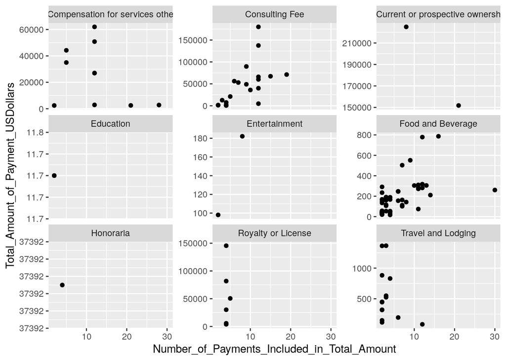

```r
# I decided to plot this last one out just for fun...
# but that required a little work for the plot to be legible.
data[data$Number_of_Payments_Included_in_Total_Amount > 1,] %>%
  # Sorry... we're about a week out from knowing this part.
  mutate(Type = strtrim(Nature_of_Payment_or_Transfer_of_Value, 30)) %>%
  # And we're about 4 weeks from seeing this stuff formally
  ggplot(aes(x = Number_of_Payments_Included_in_Total_Amount,
             y = Total_Amount_of_Payment_USDollars)) +
  geom_point() +
  facet_wrap(~Type, scales = "free_y")
```

Things that might require some cleaning: - missing data (already addressed here) - Categories that may need to be grouped or relabeled - It may be worth stripping out some of the data (e.g. the 2 payments that are to entities outside of the US) - There are a lot of different things in this dataset to begin with - anything that groups travel expenses with drug development/reimbursement/etc. is a bit heterogeneous to get useful information out of.

As the data is assembled by humans, you can just about guarantee some inconsistencies in data entry. Capitalization and punctuation are common offenders - we’ll learn how to deal with string and character manipulation in the next couple of weeks.

```r
company_names <- sort(unique(data$Applicable_Manufacturer_or_Applicable_GPO_Making_Payment_Name))
lowercase_companies <- unique(tolower(company_names))



# some capitalization issues that will interfere with aggregation
length(company_names) - length(lowercase_companies)
```

```
## [1] 4
```

```r
# some others that are just issues with abbreviations or different company divisions
company_names[116:122]
```

```
## [1] "Boehringer Ingelheim b.v."
## [2] "Boehringer Ingelheim Finland Ky"
## [3] "Boehringer Ingelheim India Pvt. Ltd."
## [4] "Boehringer Ingelheim International GmbH"
## [5] "Boehringer Ingelheim Limited"
## [6] "Boehringer Ingelheim Pharma GmbH & Co.KG"
## [7] "Boehringer Ingelheim Pharmaceuticals, Inc."
```

```r
company_names[396:397]
```

```
## [1] "Novartis Pharma AG"
## [2] "Novartis Pharmaceuticals Corporation"
```

```r
company_names[399:400]
```

```
## [1] "Novo Nordisk AS"  "Novo Nordisk Inc"
```

```r
company_names[409:411]
```

```
## [1] "Olympus America Inc."                "Olympus Corporation"
## [3] "Olympus Corporation of the Americas"
```

The `qdap` package has a `check_spelling` function which I’m sure would find some interesting issues as well.

```r
table(data$Indicate_Drug_or_Biological_or_Device_or_Medical_Supply_1, useNA = 'ifany')
```

```
##
##     Biological         Device           Drug Medical Supply           <NA>
##           2618           7335           9979             41           2329
```

```r
library(lubridate)
```

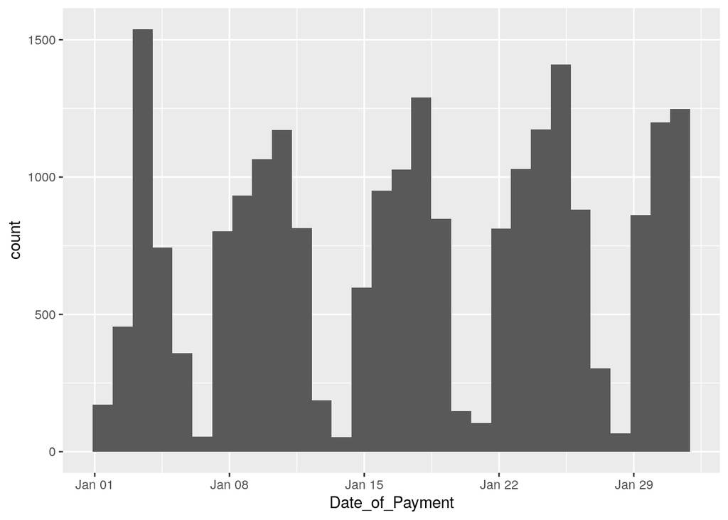

```r
# Change character date to date object
data$Date_of_Payment <- mdy(data$Date_of_Payment)
ggplot(data, aes(x = Date_of_Payment)) + stat_bin(geom = "bar")
```

### SAS

Fill in your code in the chunk below.

```
filename dat "General_Payment_Data_Sample.csv";

PROC IMPORT DATAFILE = dat OUT = openmedpay
    DBMS = CSV
    REPLACE;
    GETNAMES = YES;
    GUESSINGROWS = 22000;
RUN;

DATA WORK.openmedpay;
    SET WORK.openmedpay;
    RENAME Applicable_Manufacturer_or_Appli = payer_ID
           Var13 = payer_Name
           Var14 = payer_State
           Var15 = payer_Country;
RUN;


PROC CONTENTS DATA = WORK.openmedpay;
RUN;
```

| Data Set Name | WORK.OPENMEDPAY | Observations | 22302 |
| --- | --- | --- | --- |
| Member Type | DATA | Variables | 34 |
| Engine | V9 | Indexes | 0 |
| Created | 09/15/2020 11:52:07 | Observation Length | 1472 |
| Last Modified | 09/15/2020 11:52:07 | Deleted Observations | 0 |
| Protection |  | Compressed | NO |
| Data Set Type |  | Sorted | NO |
| Label |  |  |  |
| Data Representation | SOLARIS_X86_64, LINUX_X86_64, ALPHA_TRU64, LINUX_IA64 |  |  |
| Encoding | latin1 Western (ISO) |  |  |

| Engine/Host Dependent Information |  |
| --- | --- |
| Data Set Page Size | 122880 |
| Number of Data Set Pages | 269 |
| First Data Page | 1 |
| Max Obs per Page | 83 |
| Obs in First Data Page | 78 |
| Number of Data Set Repairs | 0 |
| Filename | /tmp/SAS_work51F800002189_silicon/openmedpay.sas7bdat |
| Release Created | 9.0401M6 |
| Host Created | Linux |
| Inode Number | 12854061 |
| Access Permission | rw-rw-r– |
| Owner Name | susan |
| File Size | 32MB |
| File Size (bytes) | 33177600 |

| Alphabetic List of Variables and Attributes # | Alphabetic List of Variables and Attributes Variable | Alphabetic List of Variables and Attributes Type | Alphabetic List of Variables and Attributes Len | Alphabetic List of Variables and Attributes Format | Alphabetic List of Variables and Attributes Informat |
| --- | --- | --- | --- | --- | --- |
| 34 | Associated_Drug_or_Biological_ND | Char | 12 | $12. | $12. |
| 1 | Change_Type | Char | 9 | $9. | $9. |
| 26 | Charity_Indicator | Char | 3 | $3. | $3. |
| 20 | City_of_Travel | Char | 20 | $20. | $20. |
| 28 | Contextual_Information | Char | 502 | $502. | $502. |
| 22 | Country_of_Travel | Char | 20 | $20. | $20. |
| 30 | Covered_or_Noncovered_Indicator_ | Char | 11 | $11. | $11. |
| 17 | Date_of_Payment | Num | 8 | MMDDYY10. | MMDDYY10. |
| 31 | Indicate_Drug_or_Biological_or_D | Char | 14 | $14. | $14. |
| 33 | Name_of_Drug_or_Biological_or_De | Char | 95 | $95. | $95. |
| 25 | Name_of_Third_Party_Entity_Recei | Char | 52 | $52. | $52. |
| 19 | Nature_of_Payment_or_Transfer_of | Char | 148 | $148. | $148. |
| 18 | Number_of_Payments_Included_in_T | Num | 8 | BEST12. | BEST32. |
| 23 | Physician_Ownership_Indicator | Char | 3 | $3. | $3. |
| 2 | Physician_Profile_ID | Num | 8 | BEST12. | BEST32. |
| 10 | Physician_Specialty | Char | 115 | $115. | $115. |
| 32 | Product_Category_or_Therapeutic_ | Char | 77 | $77. | $77. |
| 4 | Recipient_City | Char | 27 | $27. | $27. |
| 7 | Recipient_Country | Char | 18 | $18. | $18. |
| 9 | Recipient_Postal_Code | Char | 7 | $7. | $7. |
| 3 | Recipient_Primary_Business_Stree | Char | 55 | $55. | $55. |
| 8 | Recipient_Province | Char | 16 | $16. | $16. |
| 5 | Recipient_State | Char | 2 | $2. | $2. |
| 6 | Recipient_Zip_Code | Char | 10 | $10. | $10. |
| 29 | Record_ID | Num | 8 | BEST12. | BEST32. |
| 21 | State_of_Travel | Char | 2 | $2. | $2. |
| 11 | Submitting_Applicable_Manufactur | Char | 79 | $79. | $79. |
| 27 | Third_Party_Equals_Covered_Recip | Char | 3 | $3. | $3. |
| 24 | Third_Party_Payment_Recipient_In | Char | 22 | $22. | $22. |
| 16 | Total_Amount_of_Payment_USDollar | Num | 8 | BEST12. | BEST32. |
| 15 | payer_Country | Char | 18 | $18. | $18. |
| 12 | payer_ID | Num | 8 | BEST12. | BEST32. |
| 13 | payer_Name | Char | 79 | $79. | $79. |
| 14 | payer_State | Char | 2 | $2. | $2. |

First, I decided to see which states account for the majority of reimbursements by using this handy macro which outputs the top N most common entries.

```
/* Macro from https://blogs.sas.com/content/iml/2018/06/04/top-10-table-bar-chart.html */

%let TopN = 10;
%let VarName = Recipient_State;

/* no print. Create output data set of all counts */
proc freq data=WORK.openmedpay ORDER=FREQ noprint;
tables &VarName / out=TopOut;
run;

data Other;      /* keep the values for the Top categories. Use "Others" for the smaller categories */
set TopOut;
label topCat = "Top Categories or 'Other'";
length topCat $ 5; /* Allow up to 5 chars */
topCat = &VarName;       /* name of original categorical var */
if _n_ > &TopN then
    topCat = "Other";    /* merge smaller categories */
run;

proc freq data=Other ORDER=data;   /* order by data and use WEIGHT statement for counts */
  tables TopCat / plots=FreqPlot(scale=percent);
  weight Count;
run;
```

| Top Categories or ‘Other’ topCat | Top Categories or ‘Other’ Frequency | Top Categories or ‘Other’ Percent | Top Categories or ‘Other’ Cumulative Frequency | Top Categories or ‘Other’ Cumulative Percent |
| --- | --- | --- | --- | --- |
| CA | 2396 | 10.74 | 2396 | 10.74 |
| FL | 1911 | 8.57 | 4307 | 19.31 |
| TX | 1812 | 8.13 | 6119 | 27.44 |
| NY | 1734 | 7.78 | 7853 | 35.22 |
| PA | 1002 | 4.49 | 8855 | 39.71 |
| IL | 874 | 3.92 | 9729 | 43.63 |
| NC | 806 | 3.61 | 10535 | 47.24 |
| OH | 791 | 3.55 | 11326 | 50.79 |
| GA | 762 | 3.42 | 12088 | 54.21 |
| Other | 10212 | 45.79 | 22300 | 100.00 |

Frequency Missing = 2

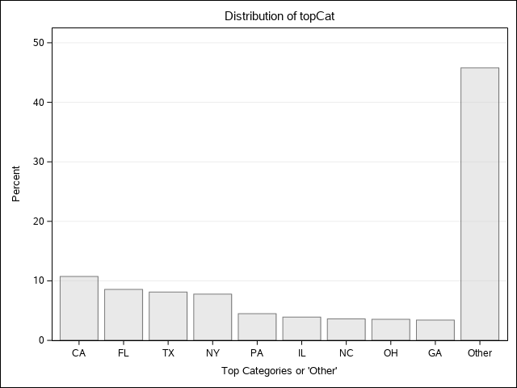

Does the total amount of payment change by state? I got my [boxplot code from a SAS support page](https://support.sas.com/kb/37/767.html#:~:text=PROC%20BOXPLOT%20does%20not%20support,vertical%20axis%20in%20PROC%20SGPLOT.)

```
6          ods graphics on / width=12in;
7          PROC SGPLOT data = WORK.openmedpay;
8            VBOX Total_Amount_of_Payment_USDollar / category =
8        ! Recipient_State;
9            YAXIS type=log logbase=10 logstyle=logexpand;
10         run;

NOTE: PROCEDURE SGPLOT used (Total process time):
      real time           2.08 seconds
      cpu time            0.18 seconds

NOTE: Marker and line antialiasing has been disabled for at least one plot
      because the threshold has been reached. You can set
      ANTIALIASMAX=4300 in the ODS GRAPHICS statement to enable
      antialiasing for all plots.
NOTE: There were 22302 observations read from the data set WORK.OPENMEDPAY.
```

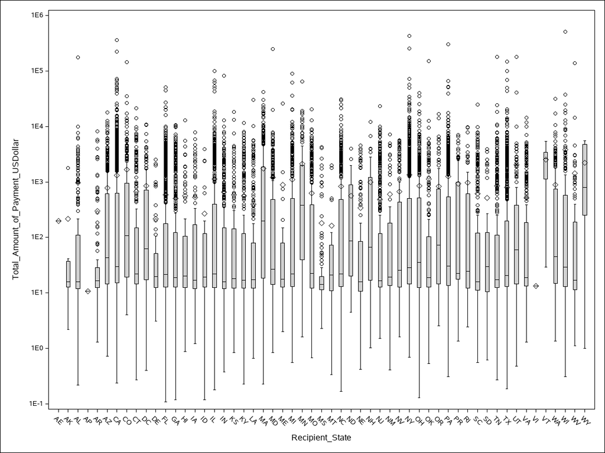

From this, I see that AE, AP, and VI are categories that have about 1 entry. AE is apparently “Armed forces Europe” and AP is “Armed Forces Pacific”, and VI is the US Virgin Islands. Any analysis we do on these probably needs to account for the limited data (so we might want to e.g. exclude those rows when modeling).

The reimbursements are oddly high for Vermont - that might be worth examining. Minnesota and Massachusetts also have a rather high average reimbursement value.

Similarly, there are relatively low reimbursements for Mississippi, Arkansas, and Alaska.

I could do some correlation plots or something, but I think I’ve found enough to investigate here to call it quits for now.